# Análisis de componentes principales

## Introducción

El Análisis de Componentes Principales (Principal Component Analysis), es una técnica multivariada que tiene como objetivo reducir la dimensionalidad, es decir, explicar con el menor número de variables posibles, la mayor cantidad de variancia del experimento. Para ello, se crea un nuevo conjunto de variables a la cual llamaremos componentes.

El PCA tiene un uso exploratorio y descriptivo.

Se emplea para variables cuantitativas.

Es la puerta de entrada para la creación de modelos inferenciales y predictivos.

## ¿Que es un componente?

Es una variable creada por la relación lineal entre distintas variables originales.

Los componentes son variables ortogonales, es decir, su correlación entre ellas es nula.

## ¿Cómo se seleccionan los componentes principales?

Se seleccionan a través de tres criterios:

- Criterio práctico: Seleccionar a los dos primeros componentes.
- Criterio de la media aritmétrica. Seleccionar a todos aquellos componentes que expliquen la variancia de más de una varible original. Es se observa en el autovalor (). Si es mayor a 1, se elige este componente como principal.
- Criterio del gráfico de sedimentación. Es muy similar al criterio de la media aritmétrica. En ese criterio se usa un gráfico en forma de media montaña, donde se observa que a medida que aumenta el número de componentes, se va disminuyendo la explicación de la variancia del componente creado.

## Aplicación: Caso Maíz

```r
Tratamiento <- factor(maiz$Tratamiento)

data.PCA <- maiz%>%
  select(HPP, GPM, LG, AG, PM)
```

### Correlación de variables

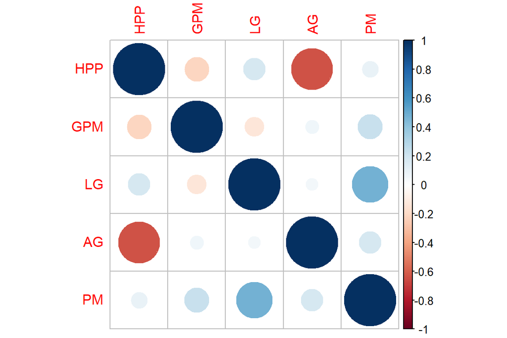

```r
cor <- cor(data.PCA)

corrplot(cor)
```

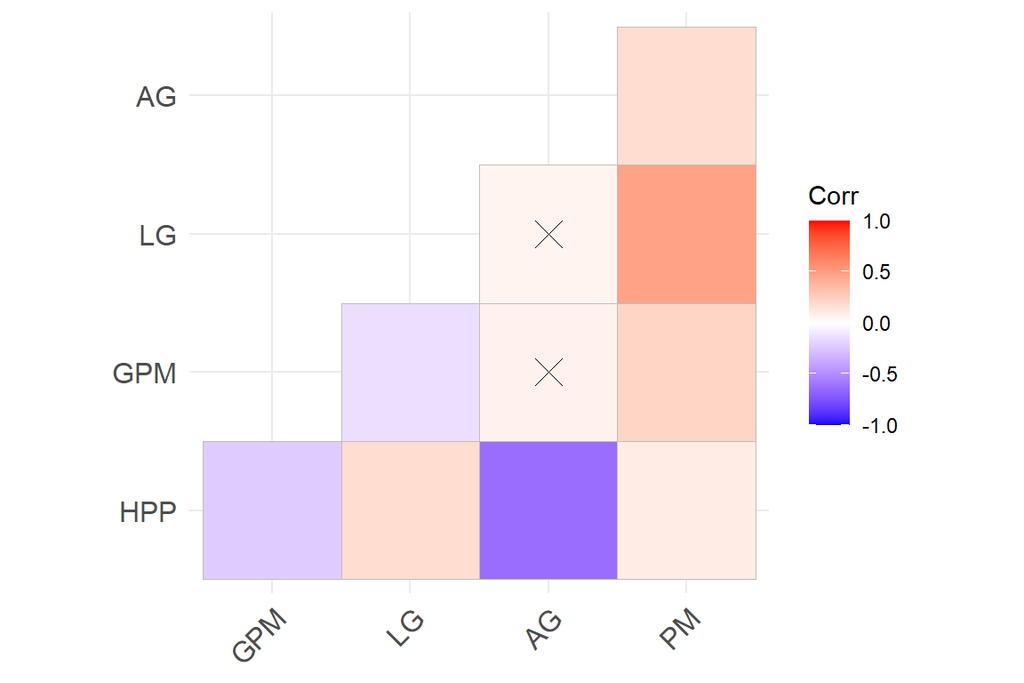

```r
p.mat <- cor_pmat(data.PCA)

ggcorrplot(cor, hc.order = F,
                    type = "lower", p.mat = p.mat)
```

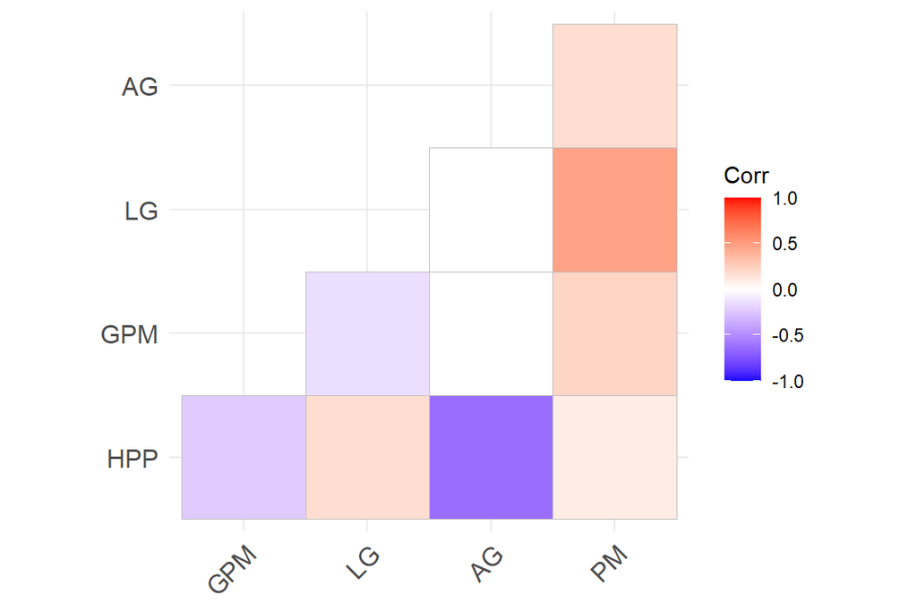

```r
ggcorrplot(cor, hc.order = F,
                    type = "lower", p.mat = p.mat,
           insig = "blank")
```

### Análisis de componentes principales

**Forma 1**

```r
acp <- FactoMineR::PCA(data.PCA, scale.unit = T, ncp = 5, graph = F)
summary(acp)
```

```
Call:
FactoMineR::PCA(X = data.PCA, scale.unit = T, ncp = 5, graph = F)


Eigenvalues
                       Dim.1   Dim.2   Dim.3   Dim.4   Dim.5
Variance               1.719   1.536   1.035   0.442   0.268
% of var.             34.386  30.713  20.699   8.846   5.356
Cumulative % of var.  34.386  65.099  85.798  94.644 100.000

Individuals (the 10 first)
        Dist    Dim.1    ctr   cos2    Dim.2    ctr   cos2    Dim.3    ctr   cos2
1   |  2.320 |  2.101  0.401  0.820 | -0.078  0.001  0.001 | -0.978  0.144  0.178 |
2   |  2.013 |  0.611  0.034  0.092 |  0.101  0.001  0.003 | -1.801  0.490  0.800 |
3   |  1.650 |  1.381  0.173  0.701 |  0.290  0.009  0.031 | -0.780  0.092  0.223 |
4   |  2.680 | -0.571  0.030  0.045 | -0.778  0.062  0.084 | -2.479  0.927  0.855 |
5   |  0.935 |  0.793  0.057  0.719 | -0.144  0.002  0.024 | -0.408  0.025  0.190 |
6   |  1.477 |  0.477  0.021  0.104 | -0.547  0.030  0.137 | -1.163  0.204  0.620 |
7   |  1.788 |  0.337  0.010  0.036 | -0.602  0.037  0.113 | -1.613  0.393  0.814 |
8   |  1.330 |  0.608  0.034  0.209 |  0.381  0.015  0.082 | -1.059  0.169  0.634 |
9   |  2.209 |  2.057  0.385  0.867 |  0.485  0.024  0.048 | -0.459  0.032  0.043 |
10  |  3.367 |  1.564  0.222  0.216 | -0.868  0.077  0.067 | -2.310  0.806  0.471 |

Variables
       Dim.1    ctr   cos2    Dim.2    ctr   cos2    Dim.3    ctr   cos2
HPP | -0.894 46.500  0.799 |  0.178  2.056  0.032 |  0.148  2.122  0.022 |
GPM |  0.417 10.104  0.174 |  0.099  0.638  0.010 |  0.870 73.208  0.758 |
LG  | -0.160  1.489  0.026 |  0.833 45.139  0.693 | -0.285  7.853  0.081 |
AG  |  0.842 41.218  0.709 |  0.185  2.223  0.034 | -0.356 12.240  0.127 |
PM  |  0.109  0.689  0.012 |  0.876 49.945  0.767 |  0.218  4.578  0.047 |
```

```r
#acp$ind$contrib
colSums(acp$ind$contrib)
```

```
Dim.1 Dim.2 Dim.3 Dim.4 Dim.5
  100   100   100   100   100
```

```r
# acp$ind$cos2
# rowSums(acp$ind$cos2)
# acp$ind$coord

acp$var$contrib
```

```
         Dim.1      Dim.2     Dim.3     Dim.4      Dim.5
HPP 46.5002070  2.0560761  2.121562  8.544112 40.7780426
GPM 10.1043069  0.6377917 73.207820  9.069750  6.9803323
LG   1.4889320 45.1390575  7.852844 44.729023  0.7901433
AG  41.2175394  2.2225611 12.239575  6.793278 37.5270458
PM   0.6890147 49.9445136  4.578199 30.863836 13.9244361
```

```r
colSums(acp$var$contrib)
```

```
Dim.1 Dim.2 Dim.3 Dim.4 Dim.5
  100   100   100   100   100
```

```r
acp$var$cos2
```

```
         Dim.1       Dim.2      Dim.3      Dim.4       Dim.5
HPP 0.79947101 0.031574032 0.02195741 0.03779034 0.109207203
GPM 0.17372182 0.009794217 0.75767480 0.04011522 0.018693947
LG  0.02559898 0.693175734 0.08127413 0.19783508 0.002116074
AG  0.70864691 0.034130651 0.12667523 0.03004646 0.100500747
PM  0.01184613 0.766970487 0.04738273 0.13650979 0.037290871
```

```r
rowSums(acp$var$cos2)
```

```
HPP GPM  LG  AG  PM
  1   1   1   1   1
```

```r
acp$var$coord
```

```
         Dim.1      Dim.2      Dim.3      Dim.4      Dim.5
HPP -0.8941314 0.17769083  0.1481803  0.1943974  0.3304651
GPM  0.4167995 0.09896574  0.8704452 -0.2002878  0.1367258
LG  -0.1599968 0.83257176 -0.2850862 -0.4447866  0.0460008
AG   0.8418117 0.18474483 -0.3559146  0.1733391  0.3170185
PM   0.1088399 0.87576851  0.2176757  0.3694723 -0.1931084
```

**Forma 2**

```r
pca <- ade4::dudi.pca(data.PCA, scannf = F, scale = T, nf = 5)
pca
```

```
Duality diagramm
class: pca dudi
$call: ade4::dudi.pca(df = data.PCA, scale = T, scannf = F, nf = 5)

$nf: 5 axis-components saved
$rank: 5
eigen values: 1.719 1.536 1.035 0.4423 0.2678
  vector length mode    content
1 $cw    5      numeric column weights
2 $lw    640    numeric row weights
3 $eig   5      numeric eigen values

  data.frame nrow ncol content
1 $tab       640  5    modified array
2 $li        640  5    row coordinates
3 $l1        640  5    row normed scores
4 $co        5    5    column coordinates
5 $c1        5    5    column normed scores
other elements: cent norm
```

```r
# pca$l1 # scores normalizados
# pca$li # scores
pca$co # coordenadas de variables
```

```
         Comp1      Comp2      Comp3      Comp4      Comp5
HPP  0.8941314 0.17769083  0.1481803 -0.1943974 -0.3304651
GPM -0.4167995 0.09896574  0.8704452  0.2002878 -0.1367258
LG   0.1599968 0.83257176 -0.2850862  0.4447866 -0.0460008
AG  -0.8418117 0.18474483 -0.3559146 -0.1733391 -0.3170185
PM  -0.1088399 0.87576851  0.2176757 -0.3694723  0.1931084
```

```r
# autovalores
summary(pca)
```

```
Class: pca dudi
Call: ade4::dudi.pca(df = data.PCA, scale = T, scannf = F, nf = 5)

Total inertia: 5

Eigenvalues:
    Ax1     Ax2     Ax3     Ax4     Ax5
 1.7193  1.5356  1.0350  0.4423  0.2678

Projected inertia (%):
    Ax1     Ax2     Ax3     Ax4     Ax5
 34.386  30.713  20.699   8.846   5.356

Cumulative projected inertia (%):
    Ax1   Ax1:2   Ax1:3   Ax1:4   Ax1:5
  34.39   65.10   85.80   94.64  100.00
```

### Gráfico de sedimentación

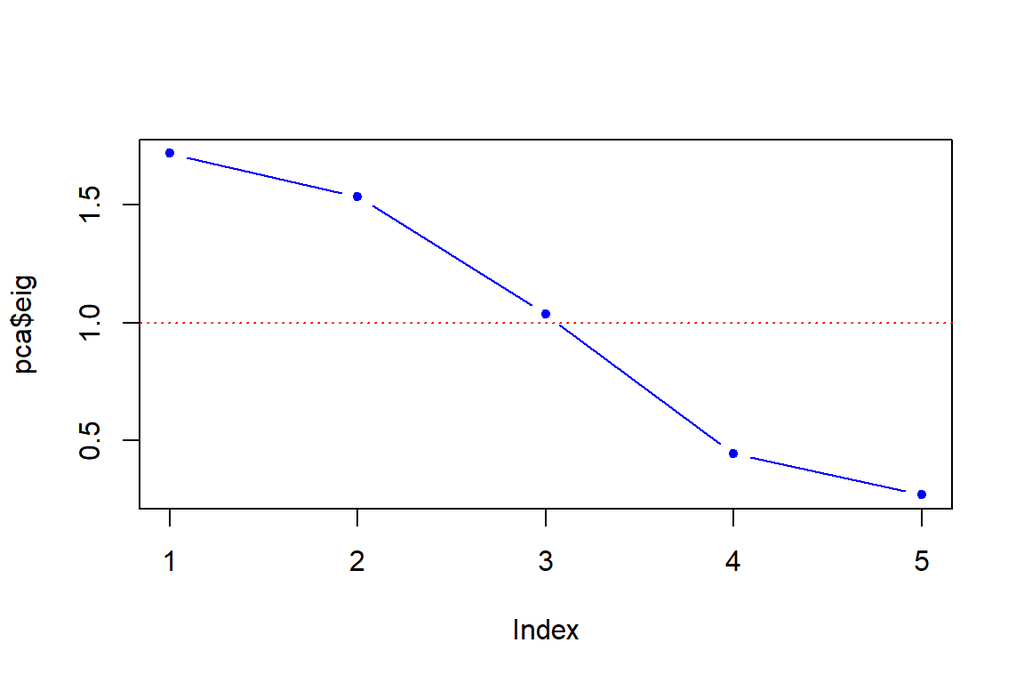

```r
# primera forma

plot(pca$eig, type = "b", pch = 20, col ="blue")
abline(h=1, lty = 3, col = "red")
```

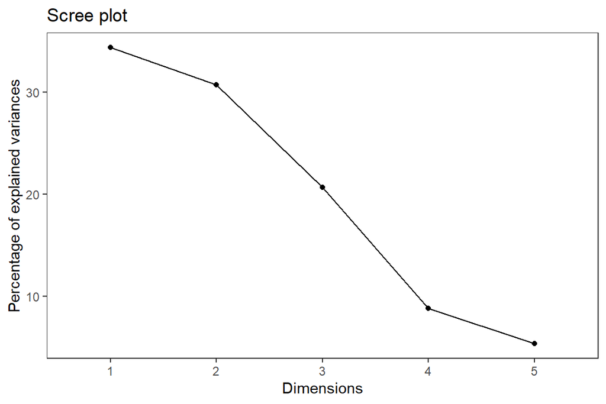

```r
fviz_eig(pca, geom = "line")+
  theme_test()
```

```r
# segunda forma

eig.val <- get_eigenvalue(pca)
eig.val
```

```
      eigenvalue variance.percent cumulative.variance.percent
Dim.1  1.7192848        34.385697                    34.38570
Dim.2  1.5356451        30.712902                    65.09860
Dim.3  1.0349643        20.699286                    85.79789
Dim.4  0.4422969         8.845938                    94.64382
Dim.5  0.2678088         5.356177                   100.00000
```

### Correlación entre variables y componentes

```r
pca$co
```

```
         Comp1      Comp2      Comp3      Comp4      Comp5
HPP  0.8941314 0.17769083  0.1481803 -0.1943974 -0.3304651
GPM -0.4167995 0.09896574  0.8704452  0.2002878 -0.1367258
LG   0.1599968 0.83257176 -0.2850862  0.4447866 -0.0460008
AG  -0.8418117 0.18474483 -0.3559146 -0.1733391 -0.3170185
PM  -0.1088399 0.87576851  0.2176757 -0.3694723  0.1931084
```

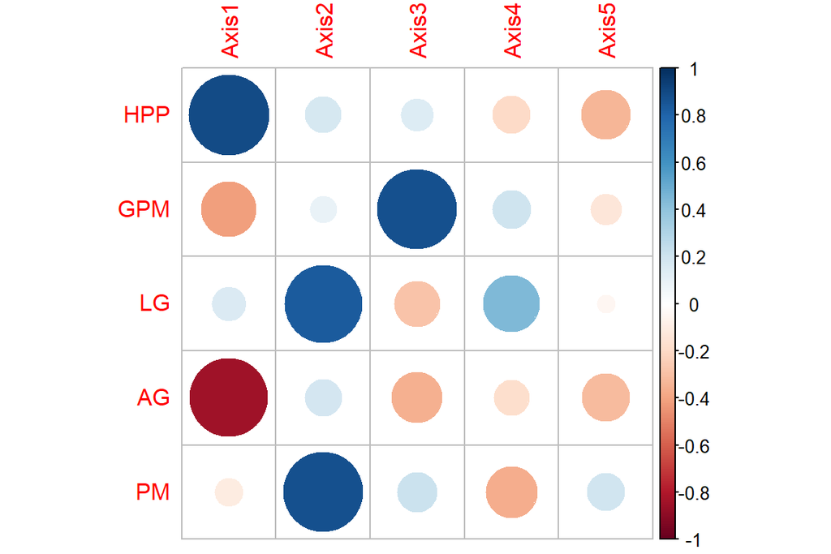

```r
corpca <- cbind(data.PCA,pca$li)

i = cor(corpca, method="pearson")

corrplot(i[1:5,6:10], sig.level = 0.05)
```

### Gráfico de variables sobre el círculo de correlaciones

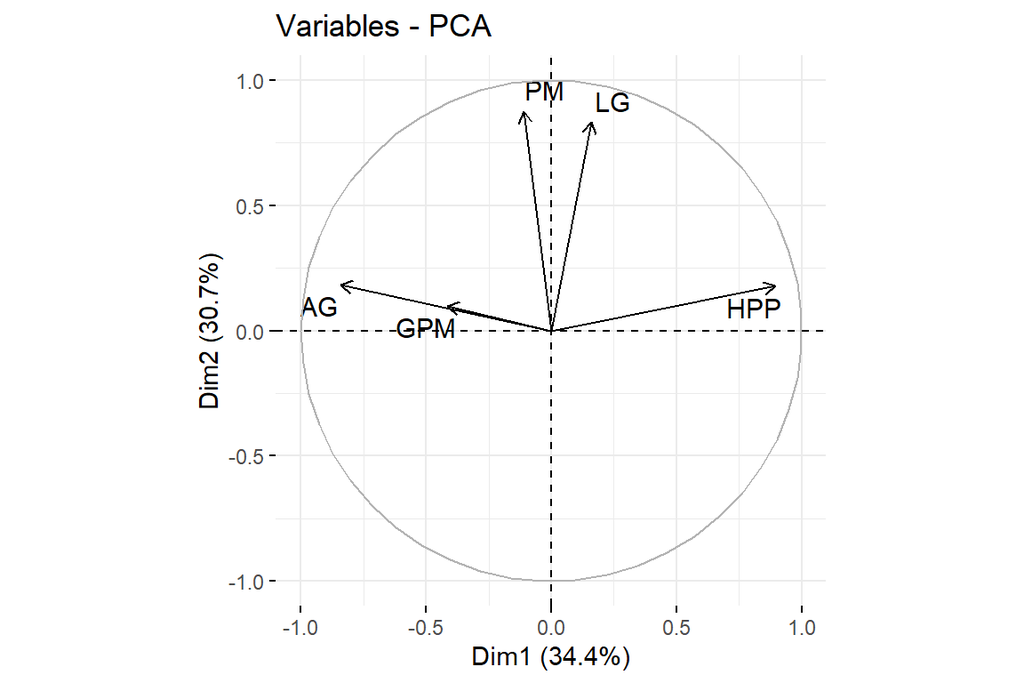

```r
fviz_pca_var(pca,repel = TRUE, axes = c(1,2))
```

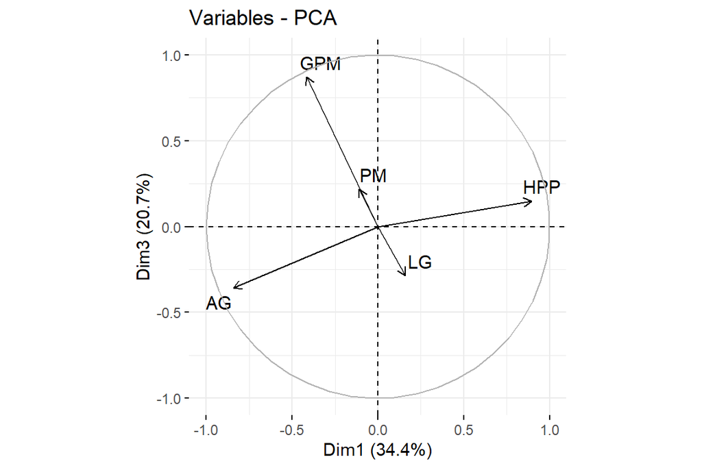

```r
fviz_pca_var(pca,repel = TRUE, axes = c(1,3))
```

### Gráfico de individuos sobre el primer plano de componentes

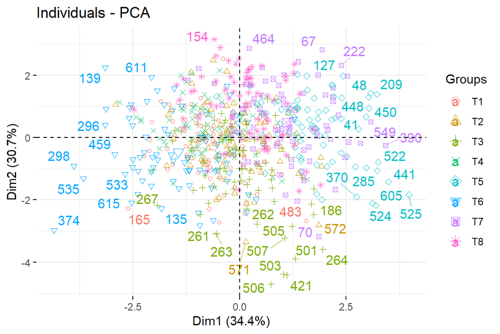

```r
fviz_pca_ind(pca,repel = TRUE,geom.ind = c("text","point"),habillage = Tratamiento)
```

### Gráfico de individuos sobre el primer plano con biplot

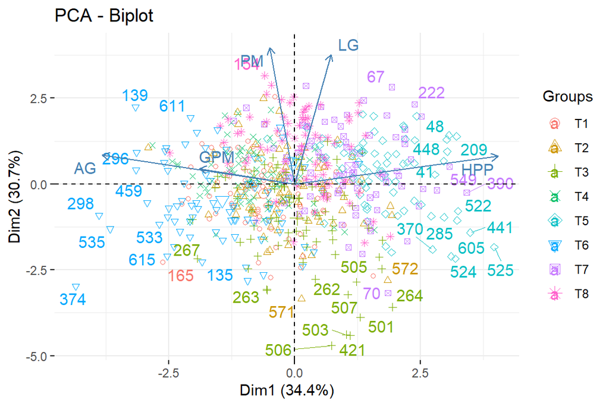

```r
fviz_pca_biplot(pca,repel = TRUE,habillage = Tratamiento)
```

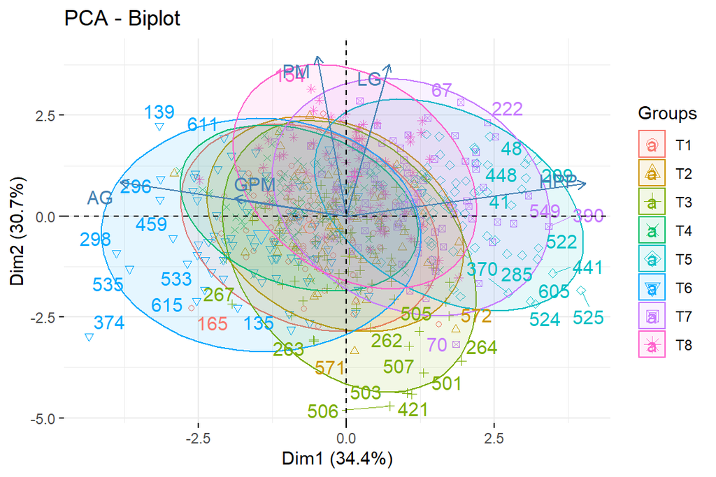

```r
fviz_pca_biplot(pca,repel = TRUE,habillage = Tratamiento, addEllipses = T)
```